#### Daily average duration by landmark for the six month period

The highest daily average duration occured in December in Palo Alto.

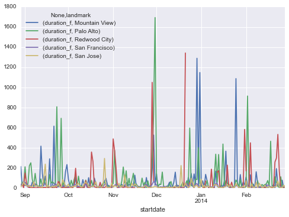

```python
dmerge4.groupby([pd.Grouper(freq='D',key='startdate'),'landmark'])[['duration_f']].mean().unstack().plot()
```

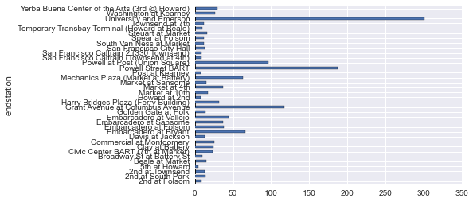

```python
dmerge4twolevels.query('startterminal == 53').groupby('endstation')['duration_f'].mean().plot(kind='barh')
```

#### Plot duration and dockcount by subscription type

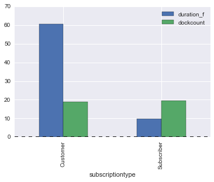

```python
grouplevel1 = dmerge4twolevels.groupby(level=1)
grouplevel1.mean()[['duration_f','dockcount']].plot(kind='bar')
```

When working with a mulitlevel index, this is one way of accessing a particular level.

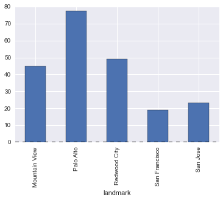

```python
dmerge4twolevels.groupby(level=['landmark']).mean()['duration_f'].plot(kind="bar")
```

#### Plot the average duration for trips that were thirty minutes and under versus trips over thirty minutes

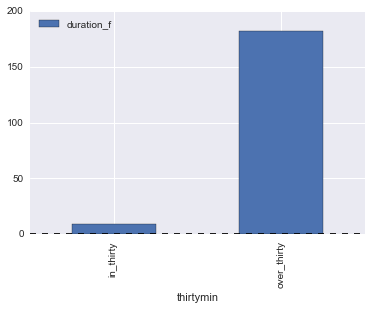

```python
dmerge4.groupby('thirtymin')[['duration_f']].mean().plot(kind='bar')
```

#### Average duration for trips thirty minutes and under compared to trips over thirty minutes faceted by time of day

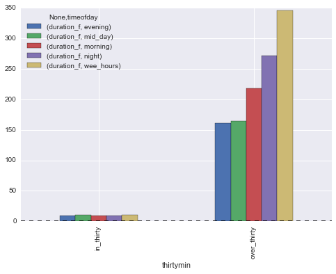

```python
dmerge4.groupby(['thirtymin','timeofday'])[['duration_f']].mean().unstack().plot(kind="bar")
```

#### Histogram of duration of trips thirty minutes and less

```
array([[<matplotlib.axes._subplots.AxesSubplot object at 0x7f39b2257790>]], dtype=object)
```

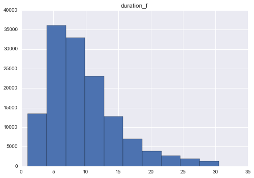

```python
dmerge4.query('thirtymin == "in_thirty"')[['duration_f']].hist()
```

#### Number of observations for each duration of thirty minutes and under

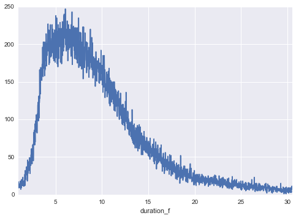

```python
dmerge4.query('thirtymin == "in_thirty"').groupby('duration_f').size().plot()
```

```
array([[<matplotlib.axes._subplots.AxesSubplot object at 0x7f39b1f53f90>]], dtype=object)
```

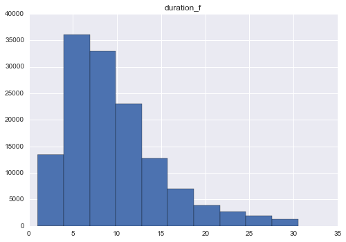

```python
#total duration of trips thrity minutes and under
dmerge4.query('thirtymin == "in_thirty"')[['duration_f']].hist()
```

#### Hourly average duration for the six month period

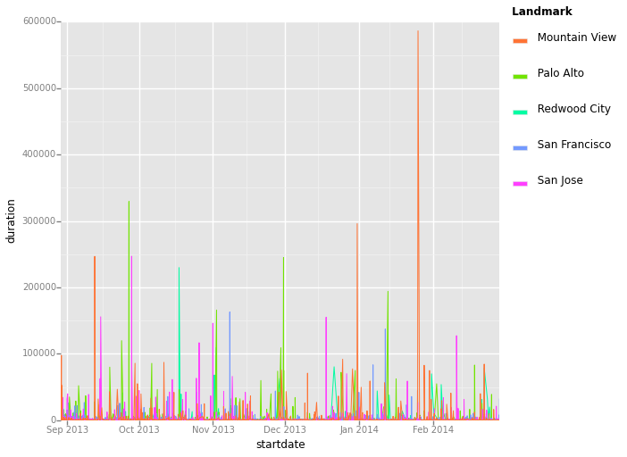

```python
hourly2 =  dmerge4.groupby([pd.Grouper(freq='H',key='startdate'),'landmark'],as_index=False).mean()
ggplot(hourly2, aes('startdate', 'duration',color='landmark')) + geom_line()
```

It's nice to see the differences by landmark. For instance, it appears that durations are higher in Palo Alto near the end of the month.

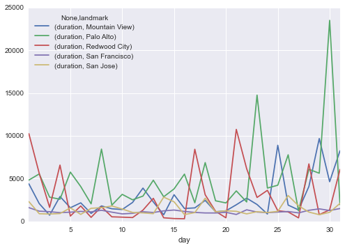

```python
#mean duration by day o the week
dmerge4.groupby(['day','landmark']).aggregate(np.mean)[['duration']].unstack().plot()
```

#### What hour of the day has the longest duration by landmark?

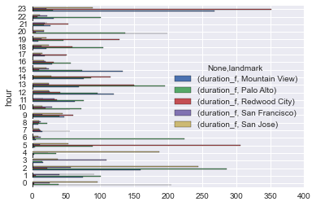

```python
#mean duration by hour of the day
dmerge4.groupby(['hour','landmark']).aggregate(np.mean)[['duration_f']].unstack().plot(kind='barh')
```

#### Average duration by hour of the day faceted by subscriber type

For every hour of the day, Customers have longer average duration than Subscribers especially in the wee hours.

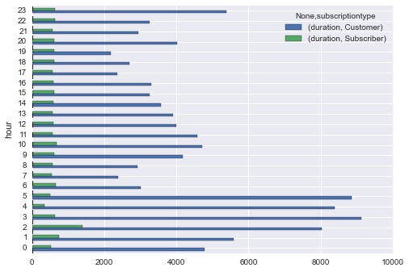

```python
#mean duration by hour of the day faceted by subscriber type
dmerge4.groupby(['hour','subscriptiontype']).aggregate(np.mean)[['duration']].unstack().plot(kind='barh')
```

#### Distribution of number of observations in the dataset by hour of the day

There were more bicycle trips taken during the morning commute and the evening commute.

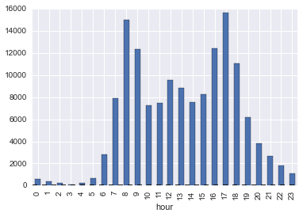

```python
hour_counts = dmerge4.groupby('hour').aggregate(np.size)
hour_counts['duration_i'].plot(kind='bar')
```

#### Distribution of total duration by hour of the day

Total duration was highest from eight am to six pm which also corresponds to working hours.

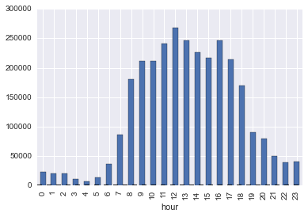

```python
hour_sum = dmerge4.groupby('hour').aggregate(np.sum)
hour_sum['duration_i'].plot(kind='bar')
```

#### Average duration by hour of the day and subscription type.

This plot indicates that subscriber trips were generally shorter while customer trips had higher durations

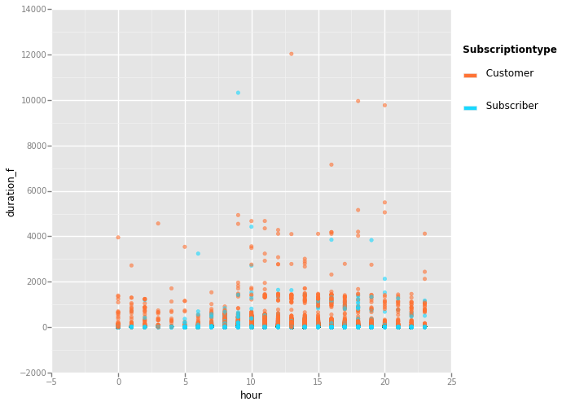

```python
from ggplot import *
ggplot(aes(x='hour', y='duration_f',color='subscriptiontype'), data=dmerge4) + \
    geom_point(alpha=.6)
```

#### Density plot of average duration by landmark

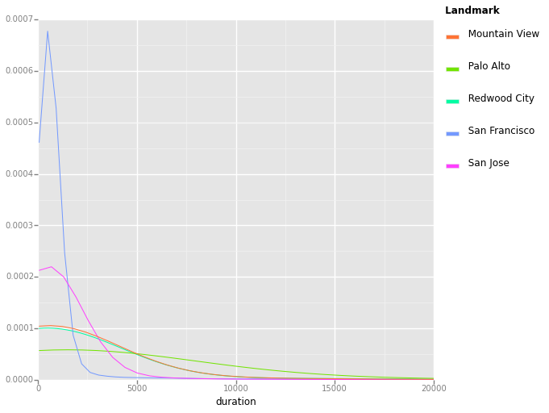

```python
ggplot(dmerge4, aes(x='duration', color='landmark')) + \
    geom_density() + xlim(0,20000)
```

#### Duration by hour for both subscription types faceted by landmark

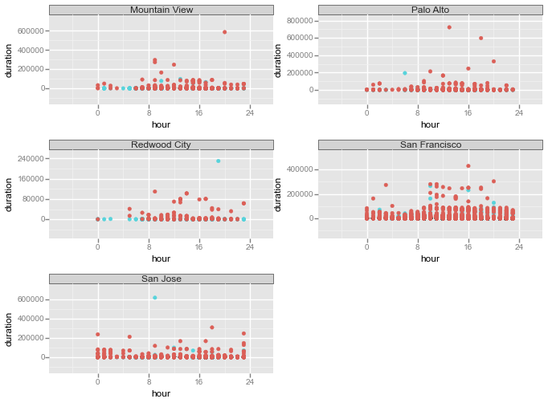

```python
ggplot(aes(x='hour', y='duration', colour='subscriptiontype'), data=dmerge4) + \
    geom_point() + facet_wrap("landmark")
```

#### Monthly total duration by landmark.

This plots illustrates that trips in San Francisco for the most part had shorter total durations while there were some outliers in Palo Alto.

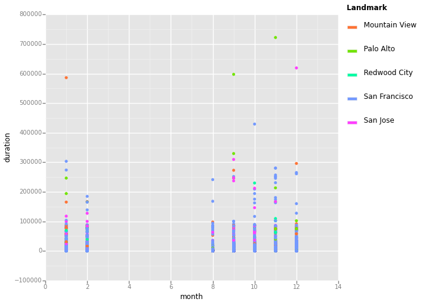

```python
ggplot(aes(x='month', y='duration', color='landmark'), data=dmerge4) + \
    geom_point()
```

#### Total duration by hour of day faceted by landmark

This type of plot makes it easier to pinpoint outliers by time of day.

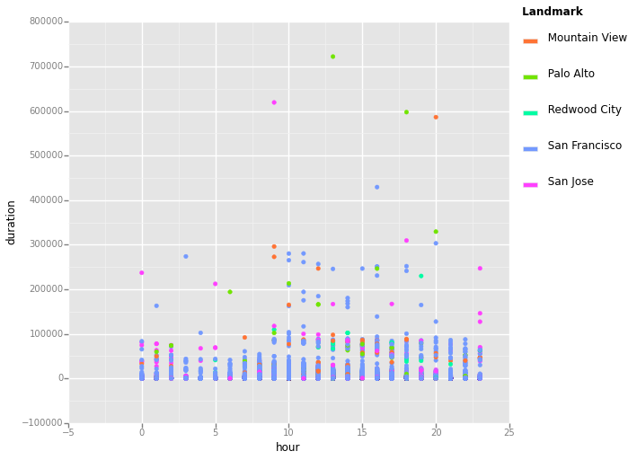

```python
ggplot(aes(x='hour', y='duration', color='landmark'), data=dmerge4) + \
    geom_point()
```

#### Plot of duration by month faceted by subscription type

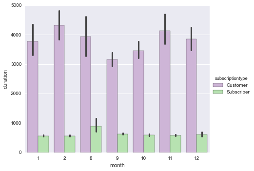

```python
sns.factorplot("month", "duration",data=dmerge4,hue="subscriptiontype",
                 palette="PRGn", aspect=1.25)
#unable to select order of x-axis(how to handle a time type in seaborn)
```

#### Plot of duration by landmark faceted by subscription type

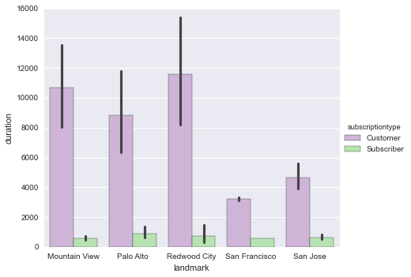

```python
sns.factorplot("landmark", "duration",data=dmerge4,hue="subscriptiontype",
                 palette="PRGn", aspect=1.25)
```

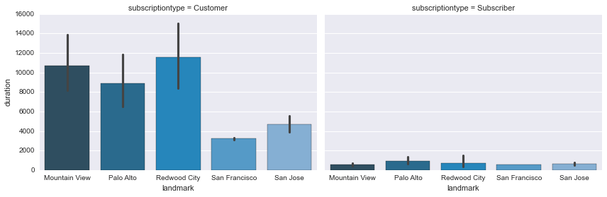

```python
sns.factorplot("landmark", "duration", col="subscriptiontype",data=dmerge4, palette="PuBu_d",size=4,aspect=1.5);
```

#### Plot of average duration by landmark faceted by subscription type

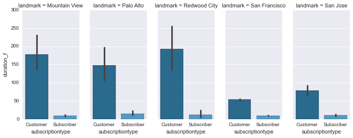

```python
sns.factorplot("subscriptiontype", "duration_f", col="landmark", data=dmerge4, palette="PuBu_d",size=4,aspect=.5);
```

#### The top five start stations

```python
dmerge4["startstation"].value_counts()[:10]
```

```
San Francisco Caltrain (Townsend at 4th)         9838
Harry Bridges Plaza (Ferry Building)             7343
Embarcadero at Sansome                           6545
Market at Sansome                                5922
Temporary Transbay Terminal (Howard at Beale)    5113
Market at 4th                                    5030
2nd at Townsend                                  4987
San Francisco Caltrain 2 (330 Townsend)          4976
Steuart at Market                                4913
Townsend at 7th                                  4493
dtype: int64
```

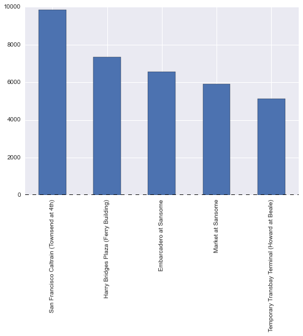

```python
dmerge4["startstation"].value_counts()[:5].plot(kind="bar")
```

#### Plot of the five lowest average durations by start station

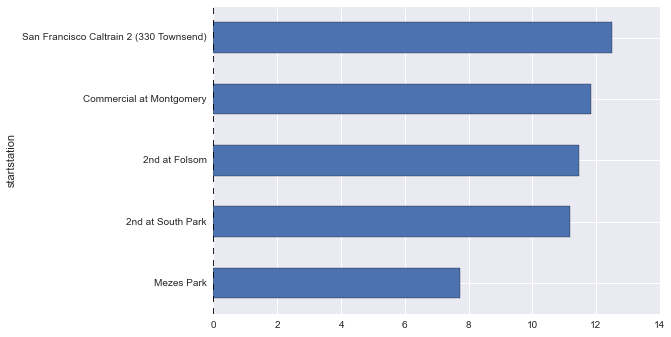

```python
dmerge4.groupby('startstation').duration_f.mean().order(ascending=True)[:5].plot(kind='barh')
```

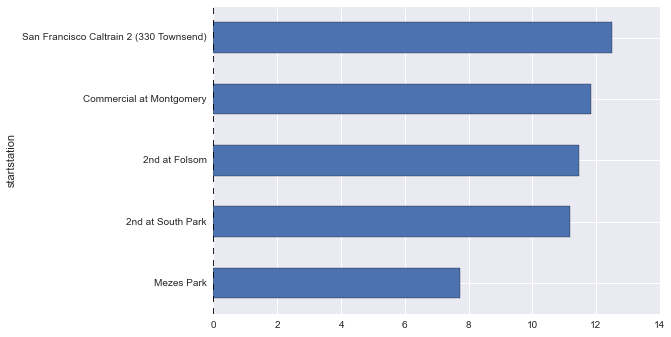

```python
#mean duration
startstation = dmerge4.groupby('startstation').duration_f.mean().order(ascending=True)[:5]
startstation.plot(kind='barh')
```

#### Plot of the total duration by landmark faceted by subscriber type

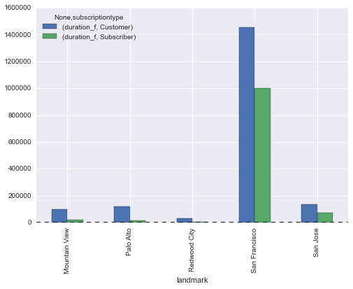

```python
dmerge4.groupby(['landmark','subscriptiontype']).agg({'duration_f' : np.sum}).unstack().plot(kind="bar")
```

#### Scatter plot with a smoothing line

This plot shows that the average dock count has a decreasing trend as mean temperature increases

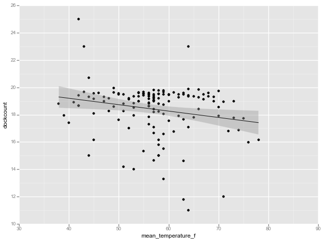

```python
#shows that avg dock count decr when mean temp incr
ggplot(h, aes(x = 'mean_temperature_f', y ='dockcount')) + geom_point() + geom_smooth(method = 'lm')
```

This work is licensed under the [Creative Commons Attribution-NonCommercial 4.0 International License](http://creativecommons.org/licenses/by-nc/4.0/).